# Analyses: Timing of Recruitment in Fire Refugia (unburned)

Anna Talucci

2019-07-19

# Overview

The purpose of this analysis is to determine when seedlings are establishing in unburned plots to see if there are any patterns in are specific increases in seedling establishment associated with mountain pine beetle outbreak.

Analysis is at the plot level. Saplings in each plot were surveyed for number of branch whorls as a proxy for age. The age of seedlings was used to calculate an establishment date. The establishment dates were used to split saplings into groups.

The second analysis used 3 groups. Saplings were grouped as either established pre-outbreak (year of establishment <1999), during outbreak (year of establishment >= 1999 and <=2006), or post outbreak (year of establishment > 2006). This increased our sample size to n=60.

The groupings created plots with repeated measures. Plots were replicates. Because of the repeated measures associated with the groupings mixed models were used for analysis with the plot as the random effect.

# Packages

The following Packages are required for the below analyses:

```r
library(dplyr)
library(tidyr)
library(ggplot2)
library(GGally)
library(MASS)
library(car)
library(lme4)
library(lsmeans)
library(DHARMa)
library(gmodels)
library(grid)
library(gridExtra)
library(gtable)
library(magick)
```

# Data

```r
whorl = read.csv("../data/chapter2_analysis2_unburnedsaplings_5december2017.csv", header=TRUE, sep = ",", strip.white = TRUE)
head(whorl)
```

|  | plot.no | date | plot.id | sapling.id | all.whorls | leader | whorl.leader | false.whorls | survey.year | est.year | est.f.year | DBH | disturbance |
| --- | --- | --- | --- | --- | --- | --- | --- | --- | --- | --- | --- | --- | --- |
| 1 | 64 | 6/30/2016 | CEC0630U1 | se1 | 16 | 1 | 17 | NA | 2016 | 1999 | 1999 | 5.5 | beetle.only |
| 2 | 64 | 6/30/2016 | CEC0630U1 | se2 | 34 | 1 | 35 | NA | 2016 | 1981 | 1981 | 7.5 | beetle.only |
| 3 | 64 | 6/30/2016 | CEC0630U1 | ne1 | 29 | 1 | 30 | NA | 2016 | 1986 | 1986 | 7.5 | beetle.only |
| 4 | 64 | 6/30/2016 | CEC0630U1 | ne2 | 28 | 1 | 29 | NA | 2016 | 1987 | 1987 | 4.5 | beetle.only |
| 5 | 64 | 6/30/2016 | CEC0630U1 | ne3 | 16 | 1 | 17 | NA | 2016 | 1999 | 1999 | 3.0 | beetle.only |
| 6 | 64 | 6/30/2016 | CEC0630U1 | ne4 | 12 | 1 | 13 | NA | 2016 | 2003 | 2003 | 1.0 | beetle.only |

```r
summary(whorl)
```

```
    plot.no             date          plot.id      sapling.id    all.whorls        leader
 Min.   :64.00   7/29/2016:111   BA0729U2 : 69   sw1    : 19   Min.   : 0.00   Min.   :0.0000
 1st Qu.:70.00   8/1/2016 : 74   BA0801U1 : 61   nw1    : 18   1st Qu.: 5.00   1st Qu.:1.0000
 Median :75.00   7/8/2016 : 73   TL0809U1 : 48   nw2    : 18   Median :10.00   Median :1.0000
 Mean   :74.53   8/12/2016: 59   BA0729U1 : 42   se1    : 18   Mean   :11.89   Mean   :0.9964
 3rd Qu.:79.00   8/9/2016 : 48   CEC0703U1: 40   ne1    : 17   3rd Qu.:16.00   3rd Qu.:1.0000
 Max.   :83.00   7/3/2016 : 40   CEC0780U2: 37   se2    : 17   Max.   :48.00   Max.   :1.0000
                 (Other)  :147   (Other)  :255   (Other):445
  whorl.leader    false.whorls     survey.year      est.year      est.f.year        DBH
 Min.   : 1.00   Min.   :0.0000   Min.   :2016   Min.   :1967   Min.   :1967   Min.   : 0.500
 1st Qu.: 6.00   1st Qu.:0.0000   1st Qu.:2016   1st Qu.:1999   1st Qu.:1998   1st Qu.: 0.500
 Median :11.00   Median :0.0000   Median :2016   Median :2005   Median :2005   Median : 1.000
 Mean   :12.89   Mean   :0.3417   Mean   :2016   Mean   :2003   Mean   :2003   Mean   : 1.699
 3rd Qu.:17.00   3rd Qu.:0.0000   3rd Qu.:2016   3rd Qu.:2010   3rd Qu.:2010   3rd Qu.: 2.000
 Max.   :49.00   Max.   :6.0000   Max.   :2016   Max.   :2015   Max.   :2015   Max.   :10.000
                 NA's   :154
      disturbance
 beetle.only:552
```

# Graphs: Data at the sapling level

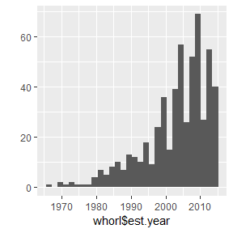

```r
qplot(x = whorl$est.year, data = whorl, geom = "histogram")
```

The above histogram for establishment year are left skewed.

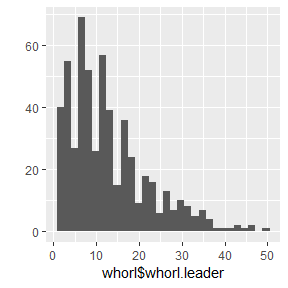

```r
qplot(x = whorl$whorl.leader, data = whorl, geom = "histogram")
```

The above histogram is right skewed for saplings age. This is just the reverse of the previous histogram.

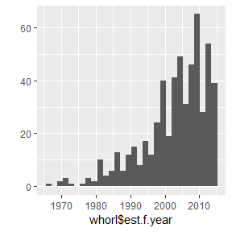

```r
qplot(x = whorl$est.f.year, data = whorl, geom = "histogram")
```

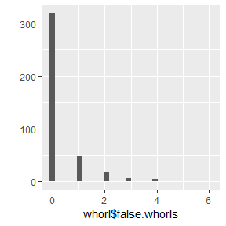

```r
qplot(x = whorl$false.whorls, data = whorl, geom = "histogram")
```

The above histogram is of false branch whorls. In some cases, PICO can put on an additional branch whorl in a growing season, referred to as a false branch whorl. It seems that large errors from false whorls are relatively small, and we had no means of confirming whether what we thought were false whorls were truly false whorls. We will acknowledge that this can happen, but we will not be taking any steps to change estimated age based on false whorls

# Data Organization

Here we will organize our data into the plot level and then have sapling establishment years with counts that we can then use for analysis.

```r
whorl$plot.no = factor(whorl$plot.no)
```

```r
summary(whorl)
```

```
    plot.no           date          plot.id      sapling.id    all.whorls        leader        whorl.leader
 74     : 69   7/29/2016:111   BA0729U2 : 69   sw1    : 19   Min.   : 0.00   Min.   :0.0000   Min.   : 1.00
 76     : 61   8/1/2016 : 74   BA0801U1 : 61   nw1    : 18   1st Qu.: 5.00   1st Qu.:1.0000   1st Qu.: 6.00
 81     : 48   7/8/2016 : 73   TL0809U1 : 48   nw2    : 18   Median :10.00   Median :1.0000   Median :11.00
 73     : 42   8/12/2016: 59   BA0729U1 : 42   se1    : 18   Mean   :11.89   Mean   :0.9964   Mean   :12.89
 66     : 40   8/9/2016 : 48   CEC0703U1: 40   ne1    : 17   3rd Qu.:16.00   3rd Qu.:1.0000   3rd Qu.:17.00
 68     : 37   7/3/2016 : 40   CEC0780U2: 37   se2    : 17   Max.   :48.00   Max.   :1.0000   Max.   :49.00
 (Other):255   (Other)  :147   (Other)  :255   (Other):445
  false.whorls     survey.year      est.year      est.f.year        DBH              disturbance
 Min.   :0.0000   Min.   :2016   Min.   :1967   Min.   :1967   Min.   : 0.500   beetle.only:552
 1st Qu.:0.0000   1st Qu.:2016   1st Qu.:1999   1st Qu.:1998   1st Qu.: 0.500
 Median :0.0000   Median :2016   Median :2005   Median :2005   Median : 1.000
 Mean   :0.3417   Mean   :2016   Mean   :2003   Mean   :2003   Mean   : 1.699
 3rd Qu.:0.0000   3rd Qu.:2016   3rd Qu.:2010   3rd Qu.:2010   3rd Qu.: 2.000
 Max.   :6.0000   Max.   :2016   Max.   :2015   Max.   :2015   Max.   :10.000
 NA's   :154
```

## Seedling/sapling age range

```r
( whorl_age = whorl %>%
  mutate(age = (2016-est.year)) )
```

| plot.no | date | plot.id | sapling.id | all.whorls | leader | whorl.leader | false.whorls | survey.year | est.year | est.f.year | DBH | disturbance | age |
| --- | --- | --- | --- | --- | --- | --- | --- | --- | --- | --- | --- | --- | --- |
| 64 | 6/30/2016 | CEC0630U1 | se1 | 16 | 1 | 17 | NA | 2016 | 1999 | 1999 | 5.5 | beetle.only | 17 |
| 64 | 6/30/2016 | CEC0630U1 | se2 | 34 | 1 | 35 | NA | 2016 | 1981 | 1981 | 7.5 | beetle.only | 35 |
| 64 | 6/30/2016 | CEC0630U1 | ne1 | 29 | 1 | 30 | NA | 2016 | 1986 | 1986 | 7.5 | beetle.only | 30 |
| 64 | 6/30/2016 | CEC0630U1 | ne2 | 28 | 1 | 29 | NA | 2016 | 1987 | 1987 | 4.5 | beetle.only | 29 |
| 64 | 6/30/2016 | CEC0630U1 | ne3 | 16 | 1 | 17 | NA | 2016 | 1999 | 1999 | 3.0 | beetle.only | 17 |
| 64 | 6/30/2016 | CEC0630U1 | ne4 | 12 | 1 | 13 | NA | 2016 | 2003 | 2003 | 1.0 | beetle.only | 13 |
| 64 | 6/30/2016 | CEC0630U1 | nw1 | 16 | 1 | 17 | NA | 2016 | 1999 | 1999 | 2.0 | beetle.only | 17 |
| 64 | 6/30/2016 | CEC0630U1 | nw2 | 26 | 1 | 27 | NA | 2016 | 1989 | 1989 | 6.0 | beetle.only | 27 |
| 64 | 6/30/2016 | CEC0630U1 | nw3 | 36 | 1 | 37 | NA | 2016 | 1979 | 1979 | 9.0 | beetle.only | 37 |
| 64 | 6/30/2016 | CEC0630U1 | sw1 | 34 | 1 | 35 | NA | 2016 | 1981 | 1981 | 8.5 | beetle.only | 35 |

[output cut: 542 more lines]

```r
median(whorl_age$age)
```

```
[1] 11
```

```r
range(whorl_age$age)
```

```
[1]  1 49
```

```r
median(whorl_age$DBH)
```

```
[1] 1
```

```r
range(whorl_age$DBH)
```

```
[1]  0.5 10.0
```

```r
( sumplot = whorl_age %>%
  group_by(plot.no) %>%
  summarise(n = n()))
```

| plot.no | n |
| --- | --- |
| 64 | 10 |
| 65 | 7 |
| 66 | 40 |
| 67 | 14 |
| 68 | 37 |
| 69 | 22 |
| 70 | 21 |
| 71 | 3 |
| 72 | 6 |
| 73 | 42 |

[output cut: 10 more lines]

```r
median(sumplot$n)
```

```
[1] 24.5
```

```r
range(sumplot$n)
```

```
[1]  3 69
```

```r
24.5*100
```

```
[1] 2450
```

We want to reorganize the data to the plot level with the number of saplings per establishment year.

```r
( plot.level = whorl %>%
  group_by(plot.no, est.year) %>%
  summarise(n = n()) %>%
  spread(est.year, n, fill = 0) )
```

| plot.no | 1967 | 1969 | 1971 | 1973 | 1974 | 1976 | 1978 | 1979 | 1980 | 1981 | 1982 | 1983 | 1984 | 1985 | 1986 | 1987 | 1988 | 1989 | 1990 | 1991 | 1992 | 1993 | 1994 | 1995 | 1996 | 1997 | 1998 | 1999 | 2000 | … |
| --- | --- | --- | --- | --- | --- | --- | --- | --- | --- | --- | --- | --- | --- | --- | --- | --- | --- | --- | --- | --- | --- | --- | --- | --- | --- | --- | --- | --- | --- | --- |
| 64 | 0 | 0 | 0 | 0 | 0 | 0 | 0 | 1 | 0 | 2 | 0 | 0 | 0 | 0 | 1 | 1 | 0 | 1 | 0 | 0 | 0 | 0 | 0 | 0 | 0 | 0 | 0 | 3 | 0 | … |
| 65 | 0 | 0 | 0 | 0 | 0 | 0 | 0 | 0 | 0 | 0 | 0 | 0 | 0 | 0 | 0 | 0 | 1 | 0 | 1 | 0 | 0 | 2 | 0 | 1 | 0 | 0 | 1 | 1 | 0 | … |
| 66 | 0 | 0 | 0 | 0 | 0 | 0 | 0 | 0 | 0 | 0 | 0 | 0 | 0 | 1 | 0 | 0 | 0 | 0 | 2 | 0 | 0 | 0 | 1 | 1 | 0 | 0 | 2 | 5 | 1 | … |
| 67 | 0 | 0 | 0 | 0 | 0 | 0 | 0 | 0 | 0 | 0 | 1 | 0 | 0 | 0 | 0 | 1 | 0 | 1 | 0 | 0 | 0 | 0 | 1 | 0 | 0 | 1 | 0 | 1 | 1 | … |
| 68 | 0 | 0 | 0 | 0 | 0 | 0 | 0 | 0 | 0 | 0 | 0 | 0 | 0 | 3 | 1 | 0 | 2 | 1 | 2 | 1 | 1 | 1 | 1 | 1 | 2 | 1 | 3 | 4 | 2 | … |
| 69 | 1 | 2 | 1 | 0 | 0 | 1 | 0 | 0 | 1 | 1 | 3 | 1 | 0 | 0 | 0 | 3 | 0 | 1 | 0 | 0 | 0 | 0 | 1 | 0 | 1 | 1 | 0 | 1 | 0 | … |
| 70 | 0 | 0 | 0 | 0 | 0 | 0 | 0 | 0 | 0 | 0 | 0 | 0 | 0 | 0 | 0 | 0 | 2 | 0 | 0 | 1 | 2 | 0 | 1 | 0 | 0 | 1 | 3 | 2 | 2 | … |
| 71 | 0 | 0 | 0 | 0 | 0 | 0 | 0 | 0 | 0 | 0 | 0 | 0 | 0 | 0 | 0 | 0 | 0 | 0 | 0 | 0 | 0 | 0 | 0 | 0 | 0 | 0 | 0 | 0 | 0 | … |
| 72 | 0 | 0 | 0 | 0 | 0 | 0 | 0 | 0 | 0 | 0 | 0 | 0 | 0 | 0 | 0 | 0 | 0 | 0 | 0 | 0 | 0 | 0 | 0 | 0 | 0 | 0 | 0 | 0 | 0 | … |
| 73 | 0 | 0 | 0 | 0 | 0 | 0 | 0 | 0 | 0 | 0 | 0 | 0 | 0 | 0 | 0 | 0 | 0 | 0 | 0 | 0 | 0 | 0 | 0 | 0 | 0 | 0 | 0 | 1 | 2 | … |

[output cut: 10 more lines]

Here we rename the columns.

```r
names(plot.level)[2:45] = c("y1967", "y1969", "y1971", "y1973", "y1974", "y1976", "y1978", "y1979", "y1980", "y1981", "y1982", "y1983", "y1984", "y1985", "y1986", "y1987", "y1988", "y1989", "y1990", "y1991", "y1992", "y1993", "y1994", "y1995", "y1996", "y1997", "y1998", "y1999", "y2000", "y2001", "y2002", "y2003", "y2004", "y2005", "y2006", "y2007", "y2008", "y2009", "y2010", "y2011", "y2012", "y2013", "y2014", "y2015")
head(plot.level)
```

| plot.no | y1967 | y1969 | y1971 | y1973 | y1974 | y1976 | y1978 | y1979 | y1980 | y1981 | y1982 | y1983 | y1984 | y1985 | y1986 | y1987 | y1988 | y1989 | y1990 | y1991 | y1992 | y1993 | y1994 | y1995 | y1996 | y1997 | y1998 | y1999 | y2000 | … |
| --- | --- | --- | --- | --- | --- | --- | --- | --- | --- | --- | --- | --- | --- | --- | --- | --- | --- | --- | --- | --- | --- | --- | --- | --- | --- | --- | --- | --- | --- | --- |
| 64 | 0 | 0 | 0 | 0 | 0 | 0 | 0 | 1 | 0 | 2 | 0 | 0 | 0 | 0 | 1 | 1 | 0 | 1 | 0 | 0 | 0 | 0 | 0 | 0 | 0 | 0 | 0 | 3 | 0 | … |
| 65 | 0 | 0 | 0 | 0 | 0 | 0 | 0 | 0 | 0 | 0 | 0 | 0 | 0 | 0 | 0 | 0 | 1 | 0 | 1 | 0 | 0 | 2 | 0 | 1 | 0 | 0 | 1 | 1 | 0 | … |
| 66 | 0 | 0 | 0 | 0 | 0 | 0 | 0 | 0 | 0 | 0 | 0 | 0 | 0 | 1 | 0 | 0 | 0 | 0 | 2 | 0 | 0 | 0 | 1 | 1 | 0 | 0 | 2 | 5 | 1 | … |
| 67 | 0 | 0 | 0 | 0 | 0 | 0 | 0 | 0 | 0 | 0 | 1 | 0 | 0 | 0 | 0 | 1 | 0 | 1 | 0 | 0 | 0 | 0 | 1 | 0 | 0 | 1 | 0 | 1 | 1 | … |
| 68 | 0 | 0 | 0 | 0 | 0 | 0 | 0 | 0 | 0 | 0 | 0 | 0 | 0 | 3 | 1 | 0 | 2 | 1 | 2 | 1 | 1 | 1 | 1 | 1 | 2 | 1 | 3 | 4 | 2 | … |
| 69 | 1 | 2 | 1 | 0 | 0 | 1 | 0 | 0 | 1 | 1 | 3 | 1 | 0 | 0 | 0 | 3 | 0 | 1 | 0 | 0 | 0 | 0 | 1 | 0 | 1 | 1 | 0 | 1 | 0 | … |

We will also add some condensed categories for establishment as pre-outbreak (before 1999) and post-outbreak (1999-2015) with 1999 being the break point as well as pre-outbreak (before 1999), during outbreak (1999-2006) and post-outbreak (2006-2015).

# Analysis

## Mixed Model with pre/during/post groupings with negative binomial

Pre 1990-1998 During 1999-2006 Post 2007-2015

### COllect the data

```r
( plot.level1990 = plot.level %>%
    mutate(pre1990 = y1990 + y1991 + y1992 + y1993 + y1994 + y1995 + y1996 + y1997 + y1998) %>%
    mutate(during1999 = y1999 + y2000 + y2001 + y2002 + y2003 + y2004 + y2005 + y2006) %>%
    mutate(post2007 =  y2007 + y2008 + y2009 + y2010 + y2011 + y2012 + y2013 + y2014 + y2015) )
```

| plot.no | y1967 | y1969 | y1971 | y1973 | y1974 | y1976 | y1978 | y1979 | y1980 | y1981 | y1982 | y1983 | y1984 | y1985 | y1986 | y1987 | y1988 | y1989 | y1990 | y1991 | y1992 | y1993 | y1994 | y1995 | y1996 | y1997 | y1998 | y1999 | y2000 | … |
| --- | --- | --- | --- | --- | --- | --- | --- | --- | --- | --- | --- | --- | --- | --- | --- | --- | --- | --- | --- | --- | --- | --- | --- | --- | --- | --- | --- | --- | --- | --- |
| 64 | 0 | 0 | 0 | 0 | 0 | 0 | 0 | 1 | 0 | 2 | 0 | 0 | 0 | 0 | 1 | 1 | 0 | 1 | 0 | 0 | 0 | 0 | 0 | 0 | 0 | 0 | 0 | 3 | 0 | … |
| 65 | 0 | 0 | 0 | 0 | 0 | 0 | 0 | 0 | 0 | 0 | 0 | 0 | 0 | 0 | 0 | 0 | 1 | 0 | 1 | 0 | 0 | 2 | 0 | 1 | 0 | 0 | 1 | 1 | 0 | … |
| 66 | 0 | 0 | 0 | 0 | 0 | 0 | 0 | 0 | 0 | 0 | 0 | 0 | 0 | 1 | 0 | 0 | 0 | 0 | 2 | 0 | 0 | 0 | 1 | 1 | 0 | 0 | 2 | 5 | 1 | … |
| 67 | 0 | 0 | 0 | 0 | 0 | 0 | 0 | 0 | 0 | 0 | 1 | 0 | 0 | 0 | 0 | 1 | 0 | 1 | 0 | 0 | 0 | 0 | 1 | 0 | 0 | 1 | 0 | 1 | 1 | … |
| 68 | 0 | 0 | 0 | 0 | 0 | 0 | 0 | 0 | 0 | 0 | 0 | 0 | 0 | 3 | 1 | 0 | 2 | 1 | 2 | 1 | 1 | 1 | 1 | 1 | 2 | 1 | 3 | 4 | 2 | … |
| 69 | 1 | 2 | 1 | 0 | 0 | 1 | 0 | 0 | 1 | 1 | 3 | 1 | 0 | 0 | 0 | 3 | 0 | 1 | 0 | 0 | 0 | 0 | 1 | 0 | 1 | 1 | 0 | 1 | 0 | … |
| 70 | 0 | 0 | 0 | 0 | 0 | 0 | 0 | 0 | 0 | 0 | 0 | 0 | 0 | 0 | 0 | 0 | 2 | 0 | 0 | 1 | 2 | 0 | 1 | 0 | 0 | 1 | 3 | 2 | 2 | … |
| 71 | 0 | 0 | 0 | 0 | 0 | 0 | 0 | 0 | 0 | 0 | 0 | 0 | 0 | 0 | 0 | 0 | 0 | 0 | 0 | 0 | 0 | 0 | 0 | 0 | 0 | 0 | 0 | 0 | 0 | … |
| 72 | 0 | 0 | 0 | 0 | 0 | 0 | 0 | 0 | 0 | 0 | 0 | 0 | 0 | 0 | 0 | 0 | 0 | 0 | 0 | 0 | 0 | 0 | 0 | 0 | 0 | 0 | 0 | 0 | 0 | … |
| 73 | 0 | 0 | 0 | 0 | 0 | 0 | 0 | 0 | 0 | 0 | 0 | 0 | 0 | 0 | 0 | 0 | 0 | 0 | 0 | 0 | 0 | 0 | 0 | 0 | 0 | 0 | 0 | 1 | 2 | … |

[output cut: 10 more lines]

## Create Pre/During/Post Data Set

```r
( dis1990 = plot.level1990 %>%
    dplyr::select(plot.no, pre1990:post2007) )
```

| plot.no | pre1990 | during1999 | post2007 |
| --- | --- | --- | --- |
| 64 | 0 | 4 | 0 |
| 65 | 5 | 1 | 0 |
| 66 | 6 | 16 | 17 |
| 67 | 2 | 4 | 5 |
| 68 | 13 | 16 | 1 |
| 69 | 3 | 1 | 3 |
| 70 | 8 | 11 | 0 |
| 71 | 0 | 1 | 2 |
| 72 | 0 | 1 | 5 |
| 73 | 0 | 18 | 24 |

[output cut: 10 more lines]

```r
( dis1990 = dis1990 %>%
    tidyr::gather(est.time, sapling.ct, pre1990:post2007) )
```

| plot.no | est.time | sapling.ct |
| --- | --- | --- |
| 64 | pre1990 | 0 |
| 65 | pre1990 | 5 |
| 66 | pre1990 | 6 |
| 67 | pre1990 | 2 |
| 68 | pre1990 | 13 |
| 69 | pre1990 | 3 |
| 70 | pre1990 | 8 |
| 71 | pre1990 | 0 |
| 72 | pre1990 | 0 |
| 73 | pre1990 | 0 |

[output cut: 50 more lines]

Here we add a column and generate a unique identifier for each group in each plot.

```r
( dis1990 = mutate(dis1990, transunique = paste(plot.no, est.time, sep = ".") ) )
```

| plot.no | est.time | sapling.ct | transunique |
| --- | --- | --- | --- |
| 64 | pre1990 | 0 | 64.pre1990 |
| 65 | pre1990 | 5 | 65.pre1990 |
| 66 | pre1990 | 6 | 66.pre1990 |
| 67 | pre1990 | 2 | 67.pre1990 |
| 68 | pre1990 | 13 | 68.pre1990 |
| 69 | pre1990 | 3 | 69.pre1990 |
| 70 | pre1990 | 8 | 70.pre1990 |
| 71 | pre1990 | 0 | 71.pre1990 |
| 72 | pre1990 | 0 | 72.pre1990 |
| 73 | pre1990 | 0 | 73.pre1990 |

[output cut: 50 more lines]

```r
dis1990$est.time = factor(dis1990$est.time, levels = c("pre1990", "during1999", "post2007"),
       labels = c("Pre (1990-1998)", "During (1999-2006)", "Post (2007-2015)"))
head(dis1990)
```

| plot.no | est.time | sapling.ct | transunique |
| --- | --- | --- | --- |
| 64 | Pre (1990-1998) | 0 | 64.pre1990 |
| 65 | Pre (1990-1998) | 5 | 65.pre1990 |
| 66 | Pre (1990-1998) | 6 | 66.pre1990 |
| 67 | Pre (1990-1998) | 2 | 67.pre1990 |
| 68 | Pre (1990-1998) | 13 | 68.pre1990 |
| 69 | Pre (1990-1998) | 3 | 69.pre1990 |

### MODEL

```r
fitdis1990 = glmer.nb(sapling.ct ~ est.time + (1 | plot.no), data = dis1990)
```

[output not shown]

### Residuals

In the plot below we are looking for the points in the QQ plot to fall along the RED linen. In the Residuals vs.predicted plot were are looking for the lines to be relatively horizontal. All looks good.

```
plotSimulatedResiduals is deprecated, switch your code to using the plot function
```

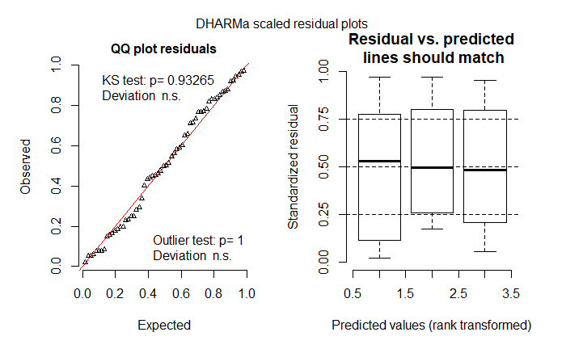

```r
plotSimulatedResiduals(simulationOutput = fitdis1990.res)
```

QQ plot looks ok with no significant deviations from the plot line. The residual vs predicted plot looks ok, lines are relatively horizontal. Th lack of horizontality maybe due to lack of data in certain regions, but these generally look adequate.

QQplot looks ok with no significant deviations. The residual vs predicted plot looks ok with lines that are relatively horizontal.

### Overdispersion

```r
simulationOutput1990 <- simulateResiduals(fittedModel = fitdis1990, refit = T, n = 20)
```

[output not shown]

```
testOverdispersion is deprecated, switch your code to using the testDispersion function
```

```
    DHARMa nonparametric dispersion test via mean deviance residual fitted vs. simulated-refitted

data:  simulationOutput
dispersion = 1.0993, p-value = 0.6
alternative hypothesis: two.sided
```

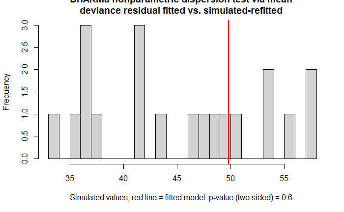

```r
testOverdispersion(simulationOutput1990)
```

### Summary

```r
summary(fitdis1990)
```

```
Generalized linear mixed model fit by maximum likelihood (Laplace Approximation) ['glmerMod']
 Family: Negative Binomial(0.7906)  ( log )
Formula: sapling.ct ~ est.time + (1 | plot.no)
   Data: dis1990

     AIC      BIC   logLik deviance df.resid
   378.4    388.9   -184.2    368.4       55

Scaled residuals:
    Min      1Q  Median      3Q     Max
-0.8616 -0.7527 -0.2775  0.4229  3.1803

Random effects:
 Groups  Name        Variance Std.Dev.
 plot.no (Intercept) 6.02e-12 2.454e-06
Number of obs: 60, groups:  plot.no, 20

Fixed effects:
                           Estimate Std. Error z value Pr(>|z|)
(Intercept)                  1.3737     0.2755   4.986 6.16e-07 ***
est.timeDuring (1999-2006)   0.7838     0.3807   2.059  0.03950 *
est.timePost (2007-2015)     1.1236     0.3785   2.969  0.00299 **
---
Signif. codes:  0 *** 0.001 ** 0.01 * 0.05 . 0.1   1

Correlation of Fixed Effects:
            (Intr) e.D(19
e.D(1999-20 -0.724
e.P(2007-20 -0.728  0.527
convergence code: 0
boundary (singular) fit: see ?isSingular
```

### Estimates

```r
lsmeans(fitdis1990, pairwise ~ est.time, type = "response", infer = TRUE, level = .95, adjust = 'bon')
```

```
$lsmeans
 est.time           response   SE  df asymp.LCL asymp.UCL
 Pre (1990-1998)        3.95 1.09 Inf      2.30      6.78
 During (1999-2006)     8.65 2.27 Inf      5.17     14.48
 Post (2007-2015)      12.15 3.15 Inf      7.31     20.21

Confidence level used: 0.95
Intervals are back-transformed from the log scale

$contrasts
 contrast                              ratio    SE  df z.ratio p.value
 Pre (1990-1998) / During (1999-2006)  0.457 0.174 Inf -2.059  0.1185
 Pre (1990-1998) / Post (2007-2015)    0.325 0.123 Inf -2.969  0.0090
 During (1999-2006) / Post (2007-2015) 0.712 0.263 Inf -0.920  1.0000

P value adjustment: bonferroni method for 3 tests
Tests are performed on the log scale
```

```r
summary(lsmeans(fitdis1990, pairwise ~ est.time), type = "response", infer = TRUE, level = .95, adjust = "bon")
```

```
$lsmeans
 est.time           response   SE  df asymp.LCL asymp.UCL z.ratio p.value
 Pre (1990-1998)        3.95 1.09 Inf      2.04      7.64 4.986   <.0001
 During (1999-2006)     8.65 2.27 Inf      4.61     16.22 8.212   <.0001
 Post (2007-2015)      12.15 3.15 Inf      6.53     22.62 9.622   <.0001

Confidence level used: 0.95
Conf-level adjustment: bonferroni method for 3 estimates
Intervals are back-transformed from the log scale
P value adjustment: bonferroni method for 3 tests
Tests are performed on the log scale

$contrasts
 contrast                              ratio    SE  df asymp.LCL asymp.UCL z.ratio p.value
 Pre (1990-1998) / During (1999-2006)  0.457 0.174 Inf     0.184     1.136 -2.059  0.1185
 Pre (1990-1998) / Post (2007-2015)    0.325 0.123 Inf     0.131     0.805 -2.969  0.0090
 During (1999-2006) / Post (2007-2015) 0.712 0.263 Inf     0.294     1.723 -0.920  1.0000

Confidence level used: 0.95
Conf-level adjustment: bonferroni method for 3 estimates
Intervals are back-transformed from the log scale
P value adjustment: bonferroni method for 3 tests
Tests are performed on the log scale
```

```r
summary(lsmeans(fitdis1990, revpairwise ~ est.time), type = "response", infer = TRUE, level = .95, adjust = "bon")
```

```
$lsmeans
 est.time           response   SE  df asymp.LCL asymp.UCL z.ratio p.value
 Pre (1990-1998)        3.95 1.09 Inf      2.04      7.64 4.986   <.0001
 During (1999-2006)     8.65 2.27 Inf      4.61     16.22 8.212   <.0001
 Post (2007-2015)      12.15 3.15 Inf      6.53     22.62 9.622   <.0001

Confidence level used: 0.95
Conf-level adjustment: bonferroni method for 3 estimates
Intervals are back-transformed from the log scale
P value adjustment: bonferroni method for 3 tests
Tests are performed on the log scale

$contrasts
 contrast                              ratio    SE  df asymp.LCL asymp.UCL z.ratio p.value
 During (1999-2006) / Pre (1990-1998)   2.19 0.834 Inf      0.88      5.45 2.059   0.1185
 Post (2007-2015) / Pre (1990-1998)     3.08 1.164 Inf      1.24      7.61 2.969   0.0090
 Post (2007-2015) / During (1999-2006)  1.40 0.519 Inf      0.58      3.40 0.920   1.0000

Confidence level used: 0.95
Conf-level adjustment: bonferroni method for 3 estimates
Intervals are back-transformed from the log scale
P value adjustment: bonferroni method for 3 tests
Tests are performed on the log scale
```

##### Data Frame

```r
( fitdis1990.graph = data.frame(summary(lsmeans(fitdis1990, pairwise ~ est.time, type = "response", infer = TRUE))) )
```

|  | lsmeans.est.time | lsmeans.response | lsmeans.SE | lsmeans.df | lsmeans.asymp.LCL | lsmeans.asymp.UCL | contrasts.contrast | contrasts.ratio | contrasts.SE | contrasts.df | contrasts.z.ratio | contrasts.p.value |
| --- | --- | --- | --- | --- | --- | --- | --- | --- | --- | --- | --- | --- |
| 1 | Pre (1990-1998) | 3.950013 | 1.088255 | Inf | 2.301902 | 6.778135 | Pre (1990-1998) / During (1999-2006) | 0.4566504 | 0.1738450 | Inf | -2.0589583 | 0.098524921 |
| 2 | During (1999-2006) | 8.649973 | 2.272582 | Inf | 5.168697 | 14.475995 | Pre (1990-1998) / Post (2007-2015) | 0.3251035 | 0.1230527 | Inf | -2.9685660 | 0.008410021 |
| 3 | Post (2007-2015) | 12.150017 | 3.153407 | Inf | 7.305612 | 20.206782 | During (1999-2006) / Post (2007-2015) | 0.7119309 | 0.2629197 | Inf | -0.9200373 | 0.627597315 |

### Figure

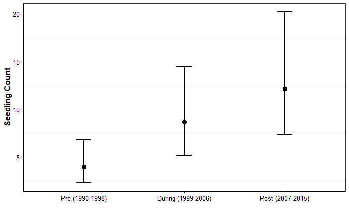

```r
( graph.estimate = ggplot(fitdis1990.graph, aes(x = lsmeans.est.time, y = lsmeans.response)) +
    geom_errorbar(width = .15, lwd=.75, aes(ymin=lsmeans.asymp.LCL, ymax=lsmeans.asymp.UCL) )  +
    geom_point(size=3) +
    ylab("Seedling Count") + xlab("") +
    theme_bw() +
    theme(legend.position = "none") +
    theme(panel.grid.major = element_blank(),
          axis.line = element_line(colour = "black")) +
    theme(axis.title.x = element_text(face = "bold", size = 12, hjust = 0.5, vjust = -0.3),
        axis.title.y = element_text(face = "bold", size = 12, hjust = 0.5, vjust = 1.1),
        axis.text.x = element_text(size = 10, color = "black"),
        axis.text.y = element_text(size = 10, color = "black"),
        axis.line = element_line(colour = "black")) +
    theme(strip.background = element_blank(), strip.text = element_blank()))
```

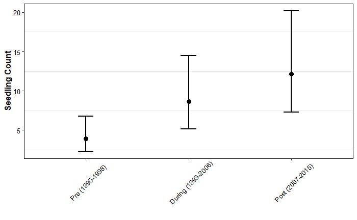

```r
( graph.estimate2 = ggplot(fitdis1990.graph, aes(x = lsmeans.est.time, y = lsmeans.response)) +
    geom_errorbar(width = .15, lwd=.75, aes(ymin=lsmeans.asymp.LCL, ymax=lsmeans.asymp.UCL) )  +
    geom_point(size=3) +
    ylab("Seedling Count") + xlab("") +
    theme_bw() +
    theme(legend.position = "none") +
    theme(panel.grid.major = element_blank(),
          axis.line = element_line(colour = "black")) +
    theme(axis.title.x = element_text(face = "bold", size = 12, hjust = 0.5, vjust = -0.3),
        axis.title.y = element_text(face = "bold", size = 12, hjust = 0.5, vjust = 1.1),
        axis.text.x = element_text(size = 10, color = "black", angle = 45, hjust = 0.45, vjust = .5),
        axis.text.y = element_text(size = 10, color = "black"),
        axis.line = element_line(colour = "black")) +
    theme(strip.background = element_blank(), strip.text = element_blank()))
```

### MODEL - not mixed

```r
fitdis1990nb = glm.nb(sapling.ct ~ est.time, data = dis1990)
```

### Residuals

In the plot below we are looking for the points in the QQ plot to fall along the RED linen. In the Residuals vs.predicted plot were are looking for the lines to be relatively horizontal. All looks good.

```
plotSimulatedResiduals is deprecated, switch your code to using the plot function
```

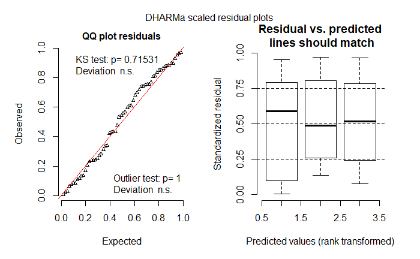

```r
plotSimulatedResiduals(simulationOutput = fitdis1990nb.res)
```

QQ plot looks ok with no significant deviations from the plot line. The residual vs predicted plot looks ok, lines are relatively horizontal. Th lack of horizontality maybe due to lack of data in certain regions, but these generally look adequate.

QQplot looks ok with no significant deviations. The residual vs predicted plot looks ok with lines that are relatively horizontal.

### Overdispersion

```
testOverdispersion is deprecated, switch your code to using the testDispersion function
```

```
    DHARMa nonparametric dispersion test via mean deviance residual fitted vs. simulated-refitted

data:  simulationOutput
dispersion = 0.86278, p-value = 0.3
alternative hypothesis: two.sided
```

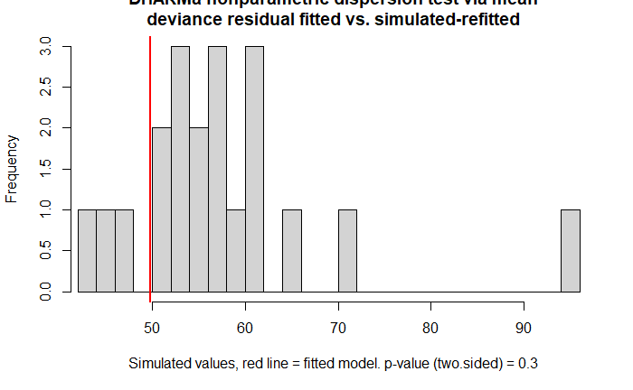

```r
simulationOutput1990nb <- simulateResiduals(fittedModel = fitdis1990nb, refit = T, n = 20)
testOverdispersion(simulationOutput1990nb)
```

### Summary

```r
summary(fitdis1990nb)
```

```
Call:
glm.nb(formula = sapling.ct ~ est.time, data = dis1990, init.theta = 0.7905699946,
    link = log)

Deviance Residuals:
    Min       1Q   Median       3Q      Max
-2.1023  -1.2800  -0.3134   0.3698   1.8028

Coefficients:
                           Estimate Std. Error z value Pr(>|z|)
(Intercept)                  1.3737     0.2755   4.986 6.16e-07 ***
est.timeDuring (1999-2006)   0.7838     0.3807   2.059  0.03950 *
est.timePost (2007-2015)     1.1236     0.3785   2.969  0.00299 **
---
Signif. codes:  0 *** 0.001 ** 0.01 * 0.05 . 0.1   1

(Dispersion parameter for Negative Binomial(0.7906) family taken to be 1)

    Null deviance: 77.730  on 59  degrees of freedom
Residual deviance: 69.154  on 57  degrees of freedom
AIC: 376.42

Number of Fisher Scoring iterations: 1

              Theta:  0.791
          Std. Err.:  0.168

 2 x log-likelihood:  -368.416
```

### Estimates

```r
lsmeans(fitdis1990nb, pairwise ~ est.time, type = "response", infer = TRUE, level = .95, adjust = 'bon')
```

```
$lsmeans
 est.time           response   SE  df asymp.LCL asymp.UCL
 Pre (1990-1998)        3.95 1.09 Inf      2.30      6.78
 During (1999-2006)     8.65 2.27 Inf      5.17     14.48
 Post (2007-2015)      12.15 3.15 Inf      7.31     20.21

Confidence level used: 0.95
Intervals are back-transformed from the log scale

$contrasts
 contrast                              ratio    SE  df z.ratio p.value
 Pre (1990-1998) / During (1999-2006)  0.457 0.174 Inf -2.059  0.1185
 Pre (1990-1998) / Post (2007-2015)    0.325 0.123 Inf -2.969  0.0090
 During (1999-2006) / Post (2007-2015) 0.712 0.263 Inf -0.920  1.0000

P value adjustment: bonferroni method for 3 tests
Tests are performed on the log scale
```

```r
summary(lsmeans(fitdis1990nb, pairwise ~ est.time), type = "response", infer = TRUE, level = .95, adjust = "bon")
```

```
$lsmeans
 est.time           response   SE  df asymp.LCL asymp.UCL z.ratio p.value
 Pre (1990-1998)        3.95 1.09 Inf      2.04      7.64 4.986   <.0001
 During (1999-2006)     8.65 2.27 Inf      4.61     16.22 8.212   <.0001
 Post (2007-2015)      12.15 3.15 Inf      6.53     22.62 9.622   <.0001

Confidence level used: 0.95
Conf-level adjustment: bonferroni method for 3 estimates
Intervals are back-transformed from the log scale
P value adjustment: bonferroni method for 3 tests
Tests are performed on the log scale

$contrasts
 contrast                              ratio    SE  df asymp.LCL asymp.UCL z.ratio p.value
 Pre (1990-1998) / During (1999-2006)  0.457 0.174 Inf     0.184     1.136 -2.059  0.1185
 Pre (1990-1998) / Post (2007-2015)    0.325 0.123 Inf     0.131     0.805 -2.969  0.0090
 During (1999-2006) / Post (2007-2015) 0.712 0.263 Inf     0.294     1.723 -0.920  1.0000

Confidence level used: 0.95
Conf-level adjustment: bonferroni method for 3 estimates
Intervals are back-transformed from the log scale
P value adjustment: bonferroni method for 3 tests
Tests are performed on the log scale
```

```r
summary(lsmeans(fitdis1990nb, revpairwise ~ est.time), type = "response", infer = TRUE, level = .95, adjust = "bon")
```

```
$lsmeans
 est.time           response   SE  df asymp.LCL asymp.UCL z.ratio p.value
 Pre (1990-1998)        3.95 1.09 Inf      2.04      7.64 4.986   <.0001
 During (1999-2006)     8.65 2.27 Inf      4.61     16.22 8.212   <.0001
 Post (2007-2015)      12.15 3.15 Inf      6.53     22.62 9.622   <.0001

Confidence level used: 0.95
Conf-level adjustment: bonferroni method for 3 estimates
Intervals are back-transformed from the log scale
P value adjustment: bonferroni method for 3 tests
Tests are performed on the log scale

$contrasts
 contrast                              ratio    SE  df asymp.LCL asymp.UCL z.ratio p.value
 During (1999-2006) / Pre (1990-1998)   2.19 0.834 Inf      0.88      5.45 2.059   0.1185
 Post (2007-2015) / Pre (1990-1998)     3.08 1.164 Inf      1.24      7.61 2.969   0.0090
 Post (2007-2015) / During (1999-2006)  1.40 0.519 Inf      0.58      3.40 0.920   1.0000

Confidence level used: 0.95
Conf-level adjustment: bonferroni method for 3 estimates
Intervals are back-transformed from the log scale
P value adjustment: bonferroni method for 3 tests
Tests are performed on the log scale
```

```r
( fitdis1990nb.graph = data.frame(summary(lsmeans(fitdis1990nb, pairwise ~ est.time, type = "response", infer = TRUE))) )
```

|  | lsmeans.est.time | lsmeans.response | lsmeans.SE | lsmeans.df | lsmeans.asymp.LCL | lsmeans.asymp.UCL | contrasts.contrast | contrasts.ratio | contrasts.SE | contrasts.df | contrasts.z.ratio | contrasts.p.value |
| --- | --- | --- | --- | --- | --- | --- | --- | --- | --- | --- | --- | --- |
| 1 | Pre (1990-1998) | 3.95 | 1.088250 | Inf | 2.301896 | 6.778108 | Pre (1990-1998) / During (1999-2006) | 0.4566474 | 0.1738439 | Inf | -2.0589745 | 0.098521362 |
| 2 | During (1999-2006) | 8.65 | 2.272595 | Inf | 5.168706 | 14.476059 | Pre (1990-1998) / Post (2007-2015) | 0.3251029 | 0.1230524 | Inf | -2.9685730 | 0.008409834 |
| 3 | Post (2007-2015) | 12.15 | 3.153404 | Inf | 7.305600 | 20.206759 | During (1999-2006) / Post (2007-2015) | 0.7119342 | 0.2629212 | Inf | -0.9200237 | 0.627605923 |

## Extract Estimates for Graph

```r
( response.graph = data.frame(summary(lsmeans(fitdis1990nb, pairwise ~ est.time), type = "response", infer = TRUE)$lsmeans))
```

|  | est.time | response | SE | df | asymp.LCL | asymp.UCL | z.ratio | p.value |
| --- | --- | --- | --- | --- | --- | --- | --- | --- |
| 1 | Pre (1990-1998) | 3.95 | 1.088250 | Inf | 2.301896 | 6.778108 | 4.986149 | 6.159465e-07 |
| 2 | During (1999-2006) | 8.65 | 2.272595 | Inf | 5.168706 | 14.476059 | 8.212150 | 2.172634e-16 |
| 3 | Post (2007-2015) | 12.15 | 3.153404 | Inf | 7.305600 | 20.206759 | 9.622156 | 6.446563e-22 |

### Figure Response Estimates

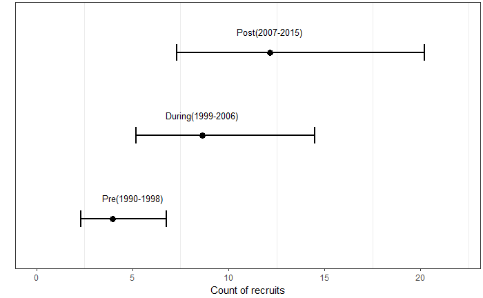

```r
(plot_time.est = ggplot(response.graph, aes(x = est.time, y = response)) +
  geom_errorbar(width = .2, lwd = .75, aes(ymin = asymp.LCL, ymax = asymp.UCL)) +
  geom_point(size = 3) +
  xlab(NULL) +
   geom_text(aes(label = c("", "","")), vjust = "inward", hjust = "inward", size = 4) +
   annotate("text", label = "During(1999-2006)", x = 2.25, y = 8.65, size = 3.5, colour = "black") +
   annotate("text", label = "Post(2007-2015)", x = 3.25, y = 12.15, size = 3.5, colour = "black") +
      annotate("text", label = "Pre(1990-1998)", x = 1.25, y = 5, size = 3.5, colour = "black") +
   scale_y_continuous(name="Count of recruits", limits=c(0, 22), breaks = c(0, 5, 10, 15, 20)) +
coord_flip() +
theme_bw() +
  theme(axis.ticks.y = element_blank(),
axis.text.y = element_blank()) +
theme(legend.position = "none") +
  theme(plot.margin = unit(c(t = 0.1, r = 0.1, b = 0.1, l = 0.5), "cm")) +
theme(panel.grid.major = element_blank() )  )
```

### Manuscript Figure: Response Estimates

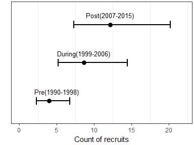

```r
(plot_time.est_ppt = ggplot(response.graph, aes(x = est.time, y = response)) +
  geom_errorbar(width = .2, lwd = .75, aes(ymin = asymp.LCL, ymax = asymp.UCL)) +
  geom_point(size = 3) +
  xlab(NULL) +
   geom_text(aes(label = c("", "","")), vjust = "inward", hjust = "inward", size = 4) +
   annotate("text", label = "During(1999-2006)", x = 2.25, y = 8.65, size = 3.5, colour = "black") +
   annotate("text", label = "Post(2007-2015)", x = 3.25, y = 12.15, size = 3.5, colour = "black") +
      annotate("text", label = "Pre(1990-1998)", x = 1.25, y = 5, size = 3.5, colour = "black") +
   scale_y_continuous(name="Count of recruits", limits=c(0, 22), breaks = c(0, 5, 10, 15, 20)) +
coord_flip() +
theme_bw() +
  theme(axis.ticks.y = element_blank(),
axis.text.y = element_blank()) +
theme(legend.position = "none") +
  theme(plot.margin = unit(c(t = 0.1, r = 0.1, b = 0.1, l = 0.5), "cm")) +
theme(panel.grid.major = element_blank() )  )
```

## Extract contrast for graph

```r
( rec.contrast = data.frame(summary(lsmeans(fitdis1990nb, revpairwise ~ est.time),type = "response", infer = TRUE)$contrasts))
```

|  | contrast | ratio | SE | df | asymp.LCL | asymp.UCL | z.ratio | p.value |
| --- | --- | --- | --- | --- | --- | --- | --- | --- |
| 1 | During (1999-2006) / Pre (1990-1998) | 2.189873 | 0.8336765 | Inf | 0.8972739 | 5.344573 | 2.0589745 | 0.098521362 |
| 2 | Post (2007-2015) / Pre (1990-1998) | 3.075949 | 1.1642558 | Inf | 1.2668279 | 7.468627 | 2.9685730 | 0.008409834 |
| 3 | Post (2007-2015) / During (1999-2006) | 1.404624 | 0.5187355 | Inf | 0.5910990 | 3.337799 | 0.9200237 | 0.627605923 |

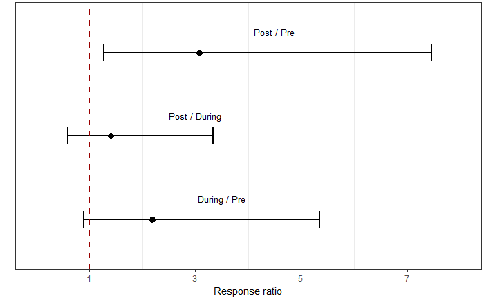

```r
(plot_time.contrast = ggplot(rec.contrast, aes(x = contrast, y = ratio)) +
  geom_errorbar(width = .2, lwd = .75, aes(ymin = asymp.LCL, ymax = asymp.UCL)) +
  geom_point(size = 3) +
  geom_hline(aes(yintercept=1), colour="#990000", linetype="dashed", size=1)  + xlab(NULL) +
   geom_text(aes(label = c("", "","")), vjust = "inward", hjust = "inward", size = 4) +
   annotate("text", label = "Post / During", x = 2.25, y = 3, size = 3.5, colour = "black") +
   annotate("text", label = "Post / Pre", x = 3.25, y = 4.5, size = 3.5, colour = "black") +
      annotate("text", label = "During / Pre", x = 1.25, y = 3.5, size = 3.5, colour = "black") +
scale_y_continuous(name="Response ratio", limits=c(0, 8), breaks = c(1, 3, 5, 7)) +
coord_flip() +
theme_bw() +
  theme(axis.ticks.y = element_blank(),
axis.text.y = element_blank()) +
theme(legend.position = "none") +
  theme(plot.margin = unit(c(t = 0.1, r = 0.1, b = 0.1, l = 0.5), "cm")) +
theme(panel.grid.major = element_blank() )  )
```

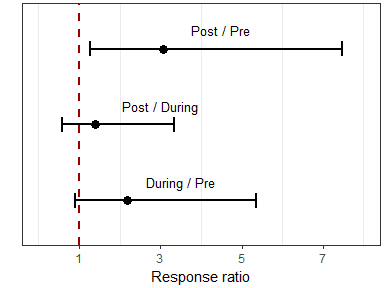

```r
(plot_time.contrast_ppt = ggplot(rec.contrast, aes(x = contrast, y = ratio)) +
  geom_errorbar(width = .2, lwd = .75, aes(ymin = asymp.LCL, ymax = asymp.UCL)) +
  geom_point(size = 3) +
  geom_hline(aes(yintercept=1), colour="#990000", linetype="dashed", size=1)  + xlab(NULL) +
   geom_text(aes(label = c("", "","")), vjust = "inward", hjust = "inward", size = 4) +
   annotate("text", label = "Post / During", x = 2.25, y = 3, size = 3.5, colour = "black") +
   annotate("text", label = "Post / Pre", x = 3.25, y = 4.5, size = 3.5, colour = "black") +
      annotate("text", label = "During / Pre", x = 1.25, y = 3.5, size = 3.5, colour = "black") +
scale_y_continuous(name="Response ratio", limits=c(0, 8), breaks = c(1, 3, 5, 7)) +
coord_flip() +
theme_bw() +
  theme(axis.ticks.y = element_blank(),
axis.text.y = element_blank()) +
theme(legend.position = "none") +
  theme(plot.margin = unit(c(t = 0.1, r = 0.1, b = 0.1, l = 0.5), "cm")) +
theme(panel.grid.major = element_blank() )  )
```

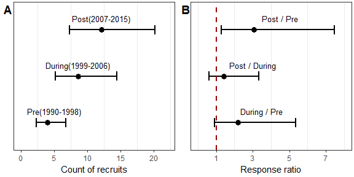

```r
(grid_time1 = cowplot::plot_grid(plot_time.est, plot_time.contrast , labels = c("A", "B"), ncol = 2))
```

** THE END **